# R Notebook

```r
rm(list=ls())

require(tidyverse)
require(dplyr)
require(pgirmess)
require(ncf)
require(geoR)
require(ggplot2)
require(terra)
require(spatstat)
# Others
```

# Background

Researchers set up a square plot with a dimension of 130 m on each side. Within the plot they established blue vane traps in a 5 m grid pattern to sample bee abundance. Every day for 10 days the researchers emptied the blue vane traps and recorded the number of bees collected. After the 10-day sampling period, they calculated the mean daily number of bees captured in the trap each day.

# Challenge 1 (2 points)

Import the blueVanes.csv file from GitHub. Plot the mean bee abundance as a function of the x and y coordinates. Upon initial inspection, does there appear to be spatial dependence in the bee response data?

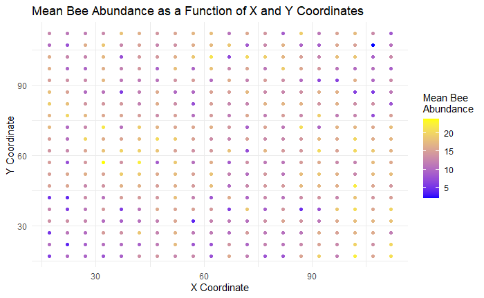

```r
# Load the data
blueVanes <- read.csv("https://raw.githubusercontent.com/ValenteJJ/SpatialEcology/main/Week6/blueVanes.csv")

# Plotting the mean bee abundance as a function of x and y coordinates
ggplot(blueVanes, aes(x = x, y = y, color = meanBee)) +
  geom_point() +
  scale_color_gradient(low = "blue", high = "yellow") +
  labs(title = "Mean Bee Abundance as a Function of X and Y Coordinates",
       x = "X Coordinate",
       y = "Y Coordinate",
       color = "Mean Bee\nAbundance") +
  theme_minimal()
```

```r
NA
NA
```

Yes, upon initial inspection, there does appear to be spatial dependence in the bee response data. Both high and low mean abundance values appear more clustered than what would be expected if the samples were spatially independent from one another.

# Challenge 2 (3 points)

Empirically test for evidence of spatial dependence in bee abundance by first building a corelogram, then building a semi-variogram. Be sure to provide an envelope for assessing whether the values in each figure are statistically different from what would be expected if the bee values were randomly distributed. Describe the patterns you see, and your interpretation with regards to the spatial dependence in mean bee abundance. Be sure to identify the maximum distance at which you should interpret your figures (2/3 of the maximum distance between points).

```r
#Create a matrix of distances
coords = cbind(blueVanes$x, blueVanes$y)
colnames(coords) = c('x', 'y')
distMat = as.matrix(dist(coords))

# Set Max Distance
maxDist = (2/3) * max(distMat)

# Create Correlogram
correlogPgirmess = pgirmess::correlog(coords, blueVanes$meanBee, method='Moran', nbclass=26, alternative = 'two.sided') #nbclass=26 because 5m*26=130m
round(correlogPgirmess, 2)
```

```
Moran I statistic
      dist.class  coef p.value     n
 [1,]       7.49  0.25    0.00  2964
 [2,]      12.46  0.18    0.00  5472
 [3,]      17.44  0.14    0.00  6392
 [4,]      22.41  0.10    0.00  7172
 [5,]      27.39 -0.01    0.64 10880
 [6,]      32.36 -0.07    0.00  9088
 [7,]      37.34 -0.08    0.00 11028
 [8,]      42.31 -0.05    0.00 11688
 [9,]      47.29 -0.05    0.00 10612
[10,]      52.26  0.00    0.95 11544
[11,]      57.24  0.00    0.85  9800
[12,]      62.21  0.02    0.05 10748
[13,]      67.19  0.01    0.36 10688
[14,]      72.16  0.01    0.31  8752
[15,]      77.14 -0.02    0.30  8052
[16,]      82.11 -0.08    0.00  6360
[17,]      87.09 -0.07    0.00  6568
[18,]      92.06 -0.10    0.00  4468
[19,]      97.04 -0.04    0.19  3256
[20,]     102.01  0.05    0.16  1776
[21,]     106.99  0.19    0.00   900
[22,]     111.96  0.18    0.00   832
[23,]     116.94  0.24    0.00   280
[24,]     121.91  0.18    0.05   220
[25,]     126.89  0.14    0.39    40
[26,]     131.86  0.08    0.56    20
```

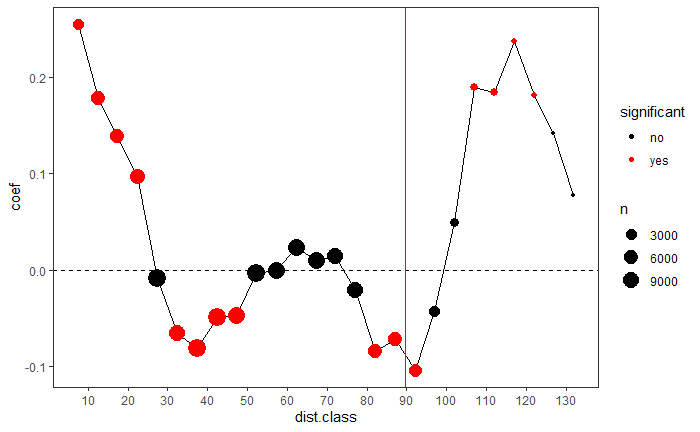

```r
# Plot Correlogram
tmp = data.frame(correlogPgirmess) %>%
  mutate(significant = ifelse(p.value < 0.05, 'yes', 'no')) # <-- In Place of Envelope

ggplot(tmp, aes(x=dist.class, y=coef))+
  geom_line()+
  geom_point(aes(color=significant, size=n))+
  scale_color_manual(values=c('black', 'red'))+
  theme_bw()+
  theme(panel.grid=element_blank())+
  geom_hline(yintercept=0, linetype='dashed')+
  geom_vline(xintercept=maxDist, color='red')+
  scale_x_continuous(breaks=seq(0, 130, 10))
```

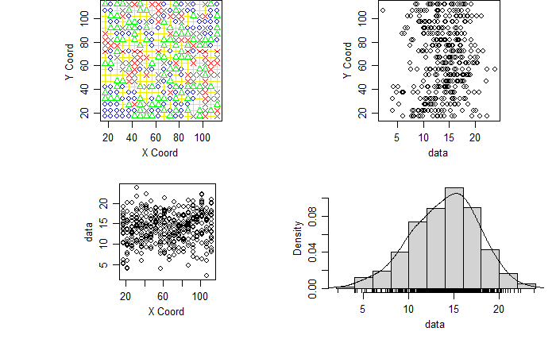

```r
# Plot geoR object
geoBee = as.geodata(blueVanes)
plot(geoBee)
```

```r
# Build Variogram
empGeor = variog(geoBee, max.dist=maxDist, breaks=seq(0, maxDist, by=5))
```

```
variog: computing omnidirectional variogram
```

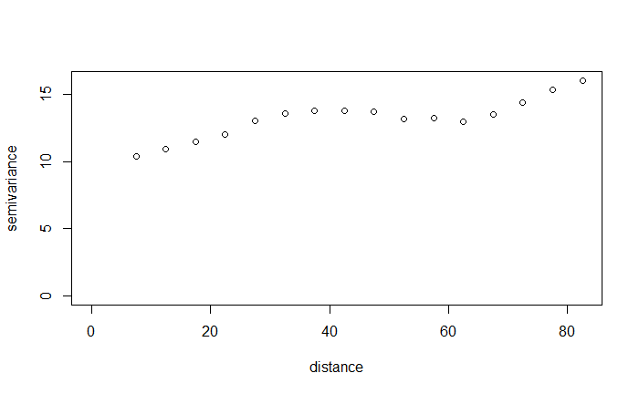

```r
plot(empGeor)
```

```r
empEnv = variog.mc.env(geoBee, obj.var=empGeor, nsim=99)
```

```
variog.env: generating 99 simulations by permutating data values
variog.env: computing the empirical variogram for the 99 simulations
variog.env: computing the envelops
```

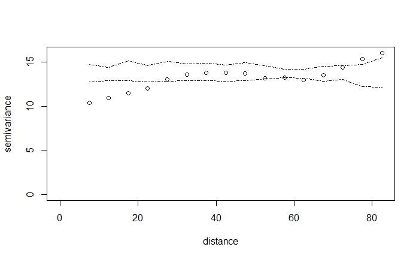

```r
plot(empGeor, envelope=empEnv)
```

```r
# Checking for anistotropy
emp4Geor = variog4(geoBee, max.dist=maxDist, direction = c(0, pi/4, pi/2, 3*pi/4))
```

```
variog: computing variogram for direction = 0 degrees (0 radians)
        tolerance angle = 22.5 degrees (0.393 radians)
variog: computing variogram for direction = 45 degrees (0.785 radians)
        tolerance angle = 22.5 degrees (0.393 radians)
variog: computing variogram for direction = 90 degrees (1.571 radians)
        tolerance angle = 22.5 degrees (0.393 radians)
variog: computing variogram for direction = 135 degrees (2.356 radians)
        tolerance angle = 22.5 degrees (0.393 radians)
variog: computing omnidirectional variogram
```

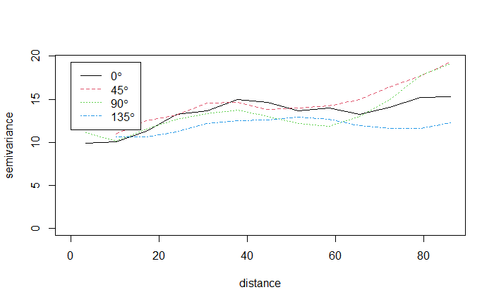

```r
plot(emp4Geor) # --> Indicates spatial covariance is similar in all directions
```

```r
#Exponential
mlExp = likfit(geoBee, cov.model='exp', ini=c(7, 60))
```

```
kappa not used for the exponential correlation function
---------------------------------------------------------------
likfit: likelihood maximisation using the function optim.
likfit: Use control() to pass additional
         arguments for the maximisation function.
        For further details see documentation for optim.
likfit: It is highly advisable to run this function several
        times with different initial values for the parameters.
likfit: WARNING: This step can be time demanding!
---------------------------------------------------------------
likfit: end of numerical maximisation.
```

```r
summary(mlExp)
```

```
Summary of the parameter estimation
-----------------------------------
Estimation method: maximum likelihood

Parameters of the mean component (trend):
   beta
13.4898

Parameters of the spatial component:
   correlation function: exponential
      (estimated) variance parameter sigmasq (partial sill) =  6.302
      (estimated) cor. fct. parameter phi (range parameter)  =  30.02
   anisotropy parameters:
      (fixed) anisotropy angle = 0  ( 0 degrees )
      (fixed) anisotropy ratio = 1

Parameter of the error component:
      (estimated) nugget =  9.098

Transformation parameter:
      (fixed) Box-Cox parameter = 1 (no transformation)

Practical Range with cor=0.05 for asymptotic range: 89.94026

Maximised Likelihood:
   log.L n.params      AIC      BIC
 "-1055"      "4"   "2118"   "2134"

non spatial model:
   log.L n.params      AIC      BIC
 "-1091"      "2"   "2186"   "2194"

Call:
likfit(geodata = geoBee, ini.cov.pars = c(7, 60), cov.model = "exp")
```

```r
#Spherical
mlSph = likfit(geoBee, cov.model='sph', ini=c(7, 60))
```

```
kappa not used for the spherical correlation function
---------------------------------------------------------------
likfit: likelihood maximisation using the function optim.
likfit: Use control() to pass additional
         arguments for the maximisation function.
        For further details see documentation for optim.
likfit: It is highly advisable to run this function several
        times with different initial values for the parameters.
likfit: WARNING: This step can be time demanding!
---------------------------------------------------------------
likfit: end of numerical maximisation.
```

```r
summary(mlSph)
```

```
Summary of the parameter estimation
-----------------------------------
Estimation method: maximum likelihood

Parameters of the mean component (trend):
   beta
13.7731

Parameters of the spatial component:
   correlation function: spherical
      (estimated) variance parameter sigmasq (partial sill) =  4.559
      (estimated) cor. fct. parameter phi (range parameter)  =  41.87
   anisotropy parameters:
      (fixed) anisotropy angle = 0  ( 0 degrees )
      (fixed) anisotropy ratio = 1

Parameter of the error component:
      (estimated) nugget =  9.201

Transformation parameter:
      (fixed) Box-Cox parameter = 1 (no transformation)

Practical Range with cor=0.05 for asymptotic range: 41.87047

Maximised Likelihood:
   log.L n.params      AIC      BIC
 "-1052"      "4"   "2112"   "2128"

non spatial model:
   log.L n.params      AIC      BIC
 "-1091"      "2"   "2186"   "2194"

Call:
likfit(geodata = geoBee, ini.cov.pars = c(7, 60), cov.model = "sph")
```

```r
#Pure Nugget -->  Model with no spatial correlation, only nugget effect. Useful for baseline comparison.
mlPN = likfit(geoBee, cov.model='pure.nugget', ini=c(7, 60))
```

```
kappa not used for the pure.nugget correlation function
---------------------------------------------------------------
likfit: likelihood maximisation using the function optim.
likfit: Use control() to pass additional
         arguments for the maximisation function.
        For further details see documentation for optim.
likfit: It is highly advisable to run this function several
        times with different initial values for the parameters.
likfit: WARNING: This step can be time demanding!
---------------------------------------------------------------
likfit: end of numerical maximisation.
```

```r
summary(mlPN)
```

```
Summary of the parameter estimation
-----------------------------------
Estimation method: maximum likelihood

Parameters of the mean component (trend):
   beta
13.9322

Parameters of the spatial component:
   correlation function: pure.nugget
      (estimated) variance parameter sigmasq (partial sill) =  13.69
      (estimated) cor. fct. parameter phi (range parameter)  =  60
   anisotropy parameters:
      (fixed) anisotropy angle = 0  ( 0 degrees )
      (fixed) anisotropy ratio = 1

Parameter of the error component:
      (estimated) nugget =  0

Transformation parameter:
      (fixed) Box-Cox parameter = 1 (no transformation)

Practical Range with cor=0.05 for asymptotic range: 0

Maximised Likelihood:
   log.L n.params      AIC      BIC
 "-1091"      "4"   "2190"   "2206"

non spatial model:
   log.L n.params      AIC      BIC
 "-1091"      "2"   "2186"   "2194"

Call:
likfit(geodata = geoBee, ini.cov.pars = c(7, 60), cov.model = "pure.nugget")
```

```r
# Compare
AIC(mlExp, mlSph, mlPN)
```

|  | df | AIC |
| --- | --- | --- |
| mlExp | 4 | 2117.788 |
| mlSph | 4 | 2112.466 |
| mlPN | 4 | 2189.712 |

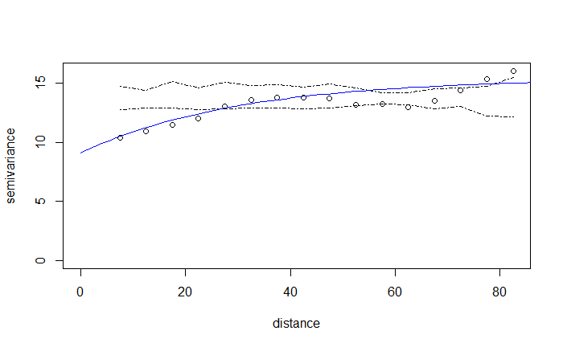

```r
plot(empGeor, envelope=empEnv)
lines(mlExp, col='blue')
```

# Challenge 3 (4 points)

Fit a simple linear model (assuming a normally distributed error term) that models mean bee abundance as a function of an intercept only (no other covariates in the model). Compare the model-estimated intercept to the bee abundance values averaged across all sites. What do you notice?

Empirically test for evidence of spatial autocorrelation IN THE MODEL RESIDUALS by first building a correlogram, then building a semi-variogram. Be sure to provide an envelope for assessing whether the values in each figure are statistically different from what would be expected if the bee values were randomly distributed in space. Compare these figures to those built for the raw data. What similarities or differences to you notice?

```r
# Fit a simple linear model with an intercept only
linearmodel <- lm(meanBee ~ 1, data = blueVanes)
summary(linearmodel)
```

```
Call:
lm(formula = meanBee ~ 1, data = blueVanes)

Residuals:
     Min       1Q   Median       3Q      Max
-11.7427  -2.5411   0.3501   2.5858   9.9204

Coefficients:
            Estimate Std. Error t value Pr(>|t|)
(Intercept)  13.9322     0.1852   75.22   <2e-16 ***
---
Signif. codes:  0 ‘***’ 0.001 ‘**’ 0.01 ‘*’ 0.05 ‘.’ 0.1 ‘ ’ 1

Residual standard error: 3.704 on 399 degrees of freedom
```

```r
# Compare the model-estimated intercept to the average bee abundance across all sites
average_bee_abundance <- mean(blueVanes$meanBee)

# Print the model-estimated intercept and the average bee abundance
model_intercept <- coef(linearmodel)[1] # Extracting the intercept from the model coefficients
print(paste("Model-estimated intercept:", model_intercept))
```

```
[1] "Model-estimated intercept: 13.9322039180302"
```

```r
print(paste("Average bee abundance across all sites:", average_bee_abundance))
```

```
[1] "Average bee abundance across all sites: 13.9322039180302"
```

The model-estimated intercept and the mean bee abundance are the exact same.

```r
#Empirically test for evidence of spatial autocorrelation IN THE MODEL RESIDUALS by first building a correlogram, then building a semi-variogram. Be sure to provide an envelope for assessing whether the values in each figure are statistically different from what would be expected if the bee values were randomly distributed in space. Compare these figures to those built for the raw data. What similarities or differences to you notice?

# Linear model residuals
linearmodel_residuals <- residuals(linearmodel)

# Create new data frame with linear model residuals in place of bee abundance column
blueVaneslm = blueVanes
blueVaneslm = blueVanes[,-3]
blueVaneslm$linearmodel_residuals = linearmodel_residuals

# Create Correlogram
lmresidual_correlog <- pgirmess::correlog(coords, blueVaneslm$linearmodel_residuals, method='Moran', nbclass=26, alternative = 'two.sided')

# Create Correlogram
correlogPgirmess_lmresid = pgirmess::correlog(coords, blueVaneslm$linearmodel_residuals, method='Moran', nbclass=26, alternative = 'two.sided') #nbclass=26 because 5m*26=130m
round(correlogPgirmess_lmresid, 2)
```

```
Moran I statistic
      dist.class  coef p.value     n
 [1,]       7.49  0.25    0.00  2964
 [2,]      12.46  0.18    0.00  5472
 [3,]      17.44  0.14    0.00  6392
 [4,]      22.41  0.10    0.00  7172
 [5,]      27.39 -0.01    0.64 10880
 [6,]      32.36 -0.07    0.00  9088
 [7,]      37.34 -0.08    0.00 11028
 [8,]      42.31 -0.05    0.00 11688
 [9,]      47.29 -0.05    0.00 10612
[10,]      52.26  0.00    0.95 11544
[11,]      57.24  0.00    0.85  9800
[12,]      62.21  0.02    0.05 10748
[13,]      67.19  0.01    0.36 10688
[14,]      72.16  0.01    0.31  8752
[15,]      77.14 -0.02    0.30  8052
[16,]      82.11 -0.08    0.00  6360
[17,]      87.09 -0.07    0.00  6568
[18,]      92.06 -0.10    0.00  4468
[19,]      97.04 -0.04    0.19  3256
[20,]     102.01  0.05    0.16  1776
[21,]     106.99  0.19    0.00   900
[22,]     111.96  0.18    0.00   832
[23,]     116.94  0.24    0.00   280
[24,]     121.91  0.18    0.05   220
[25,]     126.89  0.14    0.39    40
[26,]     131.86  0.08    0.56    20
```

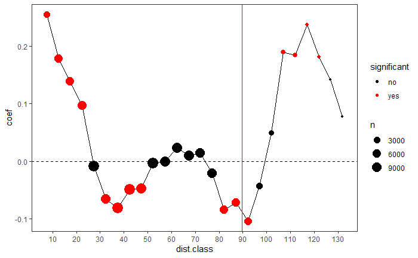

```r
# Plot Correlogram
tmp2 = data.frame(correlogPgirmess_lmresid) %>%
  mutate(significant = ifelse(p.value < 0.05, 'yes', 'no')) # <-- In Place of Envelope

ggplot(tmp2, aes(x=dist.class, y=coef))+
  geom_line()+
  geom_point(aes(color=significant, size=n))+
  scale_color_manual(values=c('black', 'red'))+
  theme_bw()+
  theme(panel.grid=element_blank())+
  geom_hline(yintercept=0, linetype='dashed')+
  geom_vline(xintercept=maxDist, color='red')+
  scale_x_continuous(breaks=seq(0, 130, 10))
```

```r
NA
NA
```

The correlogram looks exactly the same.

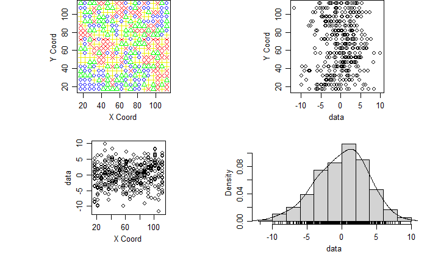

```r
#Semi-variogram
# Plot geoR object
geoBeelm = as.geodata(blueVaneslm)
plot(geoBeelm)
```

```r
# Build Variogram
empGeorlm = variog(geoBeelm, max.dist=maxDist, breaks=seq(0, maxDist, by=5))
```

```
variog: computing omnidirectional variogram
```

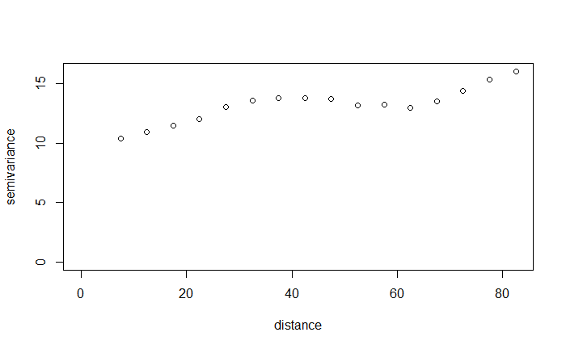

```r
plot(empGeorlm)
```

```r
empEnvlm = variog.mc.env(geoBeelm, obj.var=empGeorlm, nsim=99)
```

```
variog.env: generating 99 simulations by permutating data values
variog.env: computing the empirical variogram for the 99 simulations
variog.env: computing the envelops
```

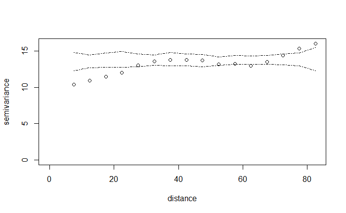

```r
plot(empGeorlm, envelope=empEnvlm)
```

Looks exactly the same

# Challenge 4 (4 points)

Conventional wisdom indicates that the distribution of floral resources may substantially influence bee abundance. In addition, I am completely making up the following fact: the average bee has a perceptual range of about 15 m. Below I have provided code for importing a raster that shows the number of flowers counted in 1 m grid cells across the entire study area. Use the focal() function from the previous lab to generate a new raster in which each cell value represents the mean number of flowers in cells within a 15 m radius. Plot the distribution of the blue vane traps over the 15 m focal raster. No text required here, just show me the plot.

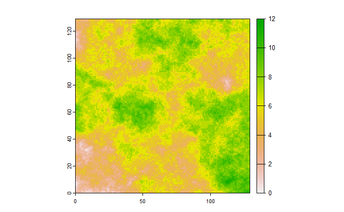

```r
floral = rast('https://github.com/ValenteJJ/SpatialEcology/raw/main/Week6/floralResources.tif')
plot(floral)
```

```r
newraster = focalMat(floral, 15, type='circle', fillNA=FALSE)
newraster
```

[output not shown]

[output cut: 113 more lines]

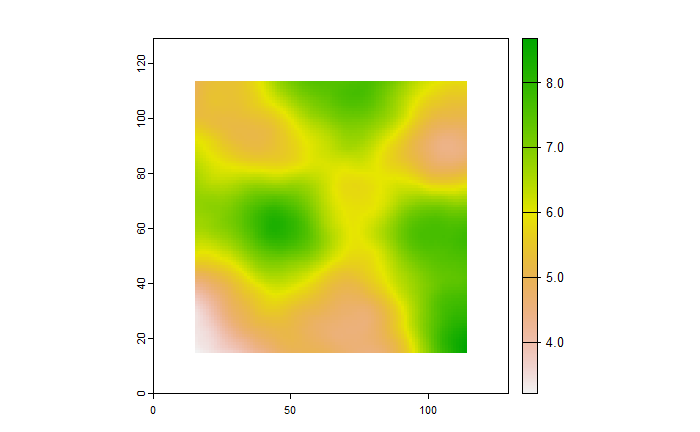

```r
FlowerDistribution = focal(floral, w = newraster, fun='sum')
plot(FlowerDistribution)
```

```r
# Convert the raster to a dataframe for plotting
FlowerDistribution_df <- as.data.frame(FlowerDistribution, xy = TRUE)

# Plot with ggplot2
ggplot() +
  geom_raster(data = FlowerDistribution_df, aes(x = x, y = y, fill = focal_mean)) +
  geom_point(data = blueVanes, aes(x = x, y = y, color = meanBee)) +
  scale_fill_viridis_c() + # Using viridis color scale for raster
  scale_color_gradient(low = "white", high = "red", name = "Mean Bee Abundance") +
  labs(title = "Flower Distribution and Mean Bee Abundance",
       x = "X Coordinate", y = "Y Coordinate") +
  theme_minimal()
```

[output not shown]

[output not shown]

No text required

# Challenge 5 (4 points)

Extract the focal flower value from the raster you just created at each point using the extract() function. You now have an estimate for the average number of flowers per meter around each blue vane trap. Fit a second linear model, but this time include average floral abundance within 15 m as a covariate. Export the residuals from this fitted model, and again, examine a corelogram and variogram of the residuals. As always, be sure to plot random envelopes. Now what do you notice?

```r
#Place your code here.
blueVaneCoords = blueVanes[,-3]
flowerextraction = extract(FlowerDistribution, blueVaneCoords)
blueVanes$meanflowers = flowerextraction$focal_mean

linearmodel_floral_covar <- lm(meanBee ~ meanflowers, data = blueVanes)



# Floral Linear model residuals
linearmodel_floral_covar_residuals <- residuals(linearmodel_floral_covar)

# Create new data frame with linear model residuals in place of bee abundance column
blueVaneslm_floral = blueVanes
blueVaneslm_floral$linearmodel_residuals_floral = linearmodel_floral_covar_residuals

# Create Correlogram
lmresidual_correlog_floral <- pgirmess::correlog(coords, blueVaneslm_floral$linearmodel_residuals_floral, method='Moran', nbclass=26, alternative = 'two.sided')
round(lmresidual_correlog_floral, 2)
```

```
Moran I statistic
      dist.class  coef p.value     n
 [1,]       7.49 -0.02    0.61  2964
 [2,]      12.46 -0.04    0.05  5472
 [3,]      17.44  0.00    0.85  6392
 [4,]      22.41  0.03    0.05  7172
 [5,]      27.39  0.00    0.77 10880
 [6,]      32.36 -0.01    0.82  9088
 [7,]      37.34 -0.01    0.38 11028
 [8,]      42.31  0.00    0.89 11688
 [9,]      47.29 -0.02    0.24 10612
[10,]      52.26  0.02    0.07 11544
[11,]      57.24  0.00    0.93  9800
[12,]      62.21  0.00    0.69 10748
[13,]      67.19 -0.01    0.44 10688
[14,]      72.16  0.01    0.36  8752
[15,]      77.14  0.02    0.19  8052
[16,]      82.11 -0.02    0.34  6360
[17,]      87.09  0.01    0.53  6568
[18,]      92.06 -0.05    0.10  4468
[19,]      97.04 -0.02    0.67  3256
[20,]     102.01 -0.01    0.98  1776
[21,]     106.99  0.06    0.18   900
[22,]     111.96 -0.01    0.89   832
[23,]     116.94  0.04    0.57   280
[24,]     121.91  0.03    0.60   220
[25,]     126.89  0.11    0.47    40
[26,]     131.86 -0.37    0.35    20
```

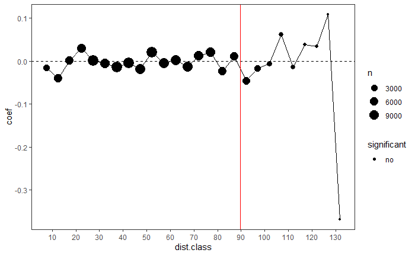

```r
# Plot Correlogram
tmp3 = data.frame(lmresidual_correlog_floral) %>%
  mutate(significant = ifelse(p.value < 0.05, 'yes', 'no')) # <-- In Place of Envelope

ggplot(tmp3, aes(x=dist.class, y=coef))+
  geom_line()+
  geom_point(aes(color=significant, size=n))+
  scale_color_manual(values=c('black', 'red'))+
  theme_bw()+
  theme(panel.grid=element_blank())+
  geom_hline(yintercept=0, linetype='dashed')+
  geom_vline(xintercept=maxDist, color='red')+
  scale_x_continuous(breaks=seq(0, 130, 10))
```

[output not shown]

```r
NA
NA
NA
```

# Challenge 6 (3 points)

What is your assessment regarding the distribution of bee abundance in this study area? Does it exhibit spatial dependence, and if so, what is driving that pattern?